# Basics

# Télécharger R et R studio

Si R est déjà installé, vérifier la version de R installée sur l’ordinateur. Pour cela : lancer Rstudio si R studio est installé et regarder la version en haut de la console :

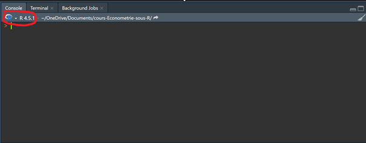

Si Rstudio n’est pas installé : exécuter R et regarder la version :

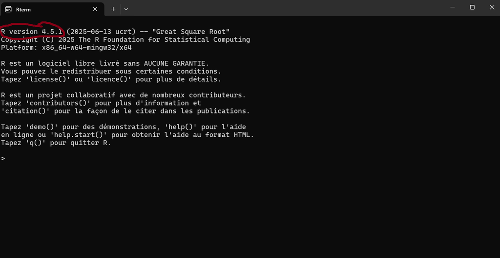

Si la version installée est inférieure à la 4.5 (4.4 etc…) ou si R n’est pas installé : Télécharger et installer le langage de programmation R : https://cran.rstudio.com

Ensuite télécharger et installer Rstudio : https://posit.co/download/rstudio-desktop/

Pour ceux qui avaient une ancienne version de R : Changer la version de R utilisée par Rstudio si la version n’est pas la bonne :

- Aller dans Tools (outils)
- Global options
- General
- Basic
- Changer la version R

[figure not shown]

[figure not shown]

Normalement vous devriez avoir une version de R supérieure à la 4.5

Pour les utilisateurs de windows télécharger Rtools 4.5 : https://cran.r-project.org/bin/windows/Rtools/rtools45/rtools.html

# Télécharger le cours

Aller sur la page github : https://github.com/Xayoux/cours-Econometrie-sous-R

Cliquer sur le bouton “Code” puis sur “Download Zip”

[figure not shown]

Ensuite : clic droit -> Extraire Tout à l’endroit voulu.

# Setup Rstudio

Ouvrir le dossier de cours et exécuter le fichier “*Econométrie sous R.Rproj”*. Cela va ouvrir Rstudio. IMPORTANT : ne pas ouvrir d’une autre manière pour ce cours.

Dans Rstudio aller dans

- Tools
- Global Options
- General -> Basic
- Décocher “Restore .Rdata into workspace at startup”
- Mettre “Save Workspace to .RData on exit :” sur “Never”

Ensuite aller dans :

- Tools
- Global Options
- Code
- Editing
- Cocher “Use native pipe operator”
- Aller dans la section Display
- Et cocher les 3 cases dans la partie “Syntax”

# Installer les packages

Ouvrez le fichier : “02-codes/utils/install-packages.R” et exécuter chaque ligne (CTRL + ENTREE) pour installer les packages.

Vérifier qu’il n’y a pas d’erreurs.

Ensuite pour revérifier : ouvrez le fichier : “02-codes/utils/setup.R” et exécuter les commandes `library()`. Vérifier qu’il n’y a pas d’erreurs.